# Final Exam

Justin Worobel

2023-12-07

## Loading CSV

```r
loan = read.csv("/Users/justinworobel/Desktop/Data180-Justin-Worobel/loan_default_data_set.csv")
```

## 1: Data Wrangling

a: What is the dimension (shape) of the dataset? How many rows and columns does the data set have?

```r
dim(loan)
```

```
## [1] 20000    21
```

```r
# 20000 rows and 21 columns
```

b: Report the column names of the data set.

```r
names(loan)
```

```
##  [1] "tot_balance"                     "avg_bal_cards"
##  [3] "credit_age"                      "credit_age_good_account"
##  [5] "credit_card_age"                 "num_acc_30d_past_due_12_months"
##  [7] "num_acc_30d_past_due_6_months"   "num_mortgage_currently_past_due"
##  [9] "tot_amount_currently_past_due"   "num_inq_12_month"
## [11] "num_card_inq_24_month"           "num_card_12_month"
## [13] "num_auto_.36_month"              "uti_open_card"
## [15] "pct_over_50_uti"                 "uti_max_credit_line"
## [17] "pct_card_over_50_uti"            "ind_XYZ"
## [19] "rep_income"                      "rep_education"
## [21] "Def_ind"
```

c: Which types of data are there in the dataset? Numeric, categorical, ordinal?

```r
# The data is mostly numeric with categorical data representing education levels
```

d: Which columns contain missing values and how much (what percent) of those columns are missing?

```r
missing = colSums(is.na(loan))
percMissing = (missing/nrow(loan)) * 100

print(missing)
```

```
##                     tot_balance                   avg_bal_cards
##                               0                               0
##                      credit_age         credit_age_good_account
##                               0                               0
##                 credit_card_age  num_acc_30d_past_due_12_months
##                               0                               0
##   num_acc_30d_past_due_6_months num_mortgage_currently_past_due
##                               0                               0
##   tot_amount_currently_past_due                num_inq_12_month
##                               0                               0
##           num_card_inq_24_month               num_card_12_month
##                               0                               0
##              num_auto_.36_month                   uti_open_card
##                               0                               0
##                 pct_over_50_uti             uti_max_credit_line
##                               0                               0
##            pct_card_over_50_uti                         ind_XYZ
##                            1958                               0
##                      rep_income                   rep_education
##                            1559                               0
##                         Def_ind
##                               0
```

```r
print(percMissing)
```

```
##                     tot_balance                   avg_bal_cards
##                           0.000                           0.000
##                      credit_age         credit_age_good_account
##                           0.000                           0.000
##                 credit_card_age  num_acc_30d_past_due_12_months
##                           0.000                           0.000
##   num_acc_30d_past_due_6_months num_mortgage_currently_past_due
##                           0.000                           0.000
##   tot_amount_currently_past_due                num_inq_12_month
##                           0.000                           0.000
##           num_card_inq_24_month               num_card_12_month
##                           0.000                           0.000
##              num_auto_.36_month                   uti_open_card
##                           0.000                           0.000
##                 pct_over_50_uti             uti_max_credit_line
##                           0.000                           0.000
##            pct_card_over_50_uti                         ind_XYZ
##                           9.790                           0.000
##                      rep_income                   rep_education
##                           7.795                           0.000
##                         Def_ind
##                           0.000
```

```r
#From this we can see that columns "pct_card_over_50_uti"(1958 missing values) and "rep_income"(1559 missing values) both have missing values. The percentage of missing values are 9.790% and 7.795% respectivley
```

e: How do you think we should deal with missing values?

```r
#We can deal with them by simply getting rid of them
loan = na.omit(loan)
```

f: With this data, would you fit a supervised or an unsupervised learning model? Why?

```r
# A supervised learning model is necesary since the data is being used to predict an outcome. In this case we are using the data to predict whether a candidate should get a loan based on numerous variables.
```

7. For part 2 and 3 drop all rows of the data that contain missing values. Print the dimensions of the resulting data set that has no missing values.

```r
loan = na.omit(loan)
dim(loan)
```

```
## [1] 16653    21
```

## 2: Data summary statistics

1. Find the summary statistics of the data set. You can use the summary function from dplyr.

```r
summary(loan)
```

```
##   tot_balance     avg_bal_cards     credit_age    credit_age_good_account
##  Min.   :     0   Min.   :    0   Min.   :  0.0   Min.   :  0.0
##  1st Qu.: 92142   1st Qu.:10135   1st Qu.:231.0   1st Qu.:120.0
##  Median :107740   Median :12237   Median :281.0   Median :146.0
##  Mean   :107503   Mean   :12226   Mean   :280.9   Mean   :146.2
##  3rd Qu.:122932   3rd Qu.:14297   3rd Qu.:330.0   3rd Qu.:172.0
##  Max.   :200000   Max.   :25000   Max.   :550.0   Max.   :300.0
##  credit_card_age num_acc_30d_past_due_12_months num_acc_30d_past_due_6_months
##  Min.   :  0.0   Min.   :0.0000                 Min.   :0.00000
##  1st Qu.:242.0   1st Qu.:0.0000                 1st Qu.:0.00000
##  Median :285.0   Median :0.0000                 Median :0.00000
##  Mean   :285.4   Mean   :0.1579                 Mean   :0.02936
##  3rd Qu.:330.0   3rd Qu.:0.0000                 3rd Qu.:0.00000
##  Max.   :550.0   Max.   :5.0000                 Max.   :2.00000
##  num_mortgage_currently_past_due tot_amount_currently_past_due
##  Min.   :0.0000                  Min.   :    0.0
##  1st Qu.:0.0000                  1st Qu.:    0.0
##  Median :0.0000                  Median :    0.0
##  Mean   :0.0299                  Mean   :  354.2
##  3rd Qu.:0.0000                  3rd Qu.:    0.0
##  Max.   :1.0000                  Max.   :35000.0
##  num_inq_12_month  num_card_inq_24_month num_card_12_month num_auto_.36_month
##  Min.   : 0.0000   Min.   : 0.000        Min.   :0.0000    Min.   :0.000
##  1st Qu.: 0.0000   1st Qu.: 0.000        1st Qu.:0.0000    1st Qu.:0.000
##  Median : 0.0000   Median : 0.000        Median :0.0000    Median :0.000
##  Mean   : 0.6133   Mean   : 1.044        Mean   :0.2723    Mean   :0.165
##  3rd Qu.: 1.0000   3rd Qu.: 1.000        3rd Qu.:1.0000    3rd Qu.:0.000
##  Max.   :10.0000   Max.   :18.000        Max.   :3.0000    Max.   :2.000
##  uti_open_card    pct_over_50_uti  uti_max_credit_line pct_card_over_50_uti
##  Min.   :0.0000   Min.   :0.0000   Min.   :0.0000      Min.   :0.0000
##  1st Qu.:0.4048   1st Qu.:0.4011   1st Qu.:0.3778      1st Qu.:0.4643
##  Median :0.4909   Median :0.4855   Median :0.4649      Median :0.5518
##  Mean   :0.4914   Mean   :0.4842   Mean   :0.4653      Mean   :0.5511
##  3rd Qu.:0.5783   3rd Qu.:0.5679   3rd Qu.:0.5541      3rd Qu.:0.6384
##  Max.   :1.0000   Max.   :0.9294   Max.   :1.0000      Max.   :1.0000
##     ind_XYZ         rep_income     rep_education         Def_ind
##  Min.   :0.0000   Min.   : 20000   Length:16653       Min.   :0.0000
##  1st Qu.:0.0000   1st Qu.:143751   Class :character   1st Qu.:0.0000
##  Median :0.0000   Median :166630   Mode  :character   Median :0.0000
##  Mean   :0.2487   Mean   :166504                      Mean   :0.1019
##  3rd Qu.:0.0000   3rd Qu.:189020                      3rd Qu.:0.0000
##  Max.   :1.0000   Max.   :300000                      Max.   :1.0000
```

2. Based on the mean, mode, and median, is “num_card_inq_24_month” bell shaped, left, right skewed? How about “tot_amount_currently_past_due”? “credit_age”?

```r
# -“num_card_inq_24_month” median = 0 and mean = 1.044 making it right skewed since the mean is greater
# -“tot_amount_currently_past_due” median = 0 mean = 354.2 making it right skewed
# - “credit_age” median = 281 mean = 280.9 making it VERY slightly left skewed but should be approximated as bell-shaped
```

3. Plot a histogram of the variables in b above. Do the shapes of the histograms confirm the skewness you found in b?

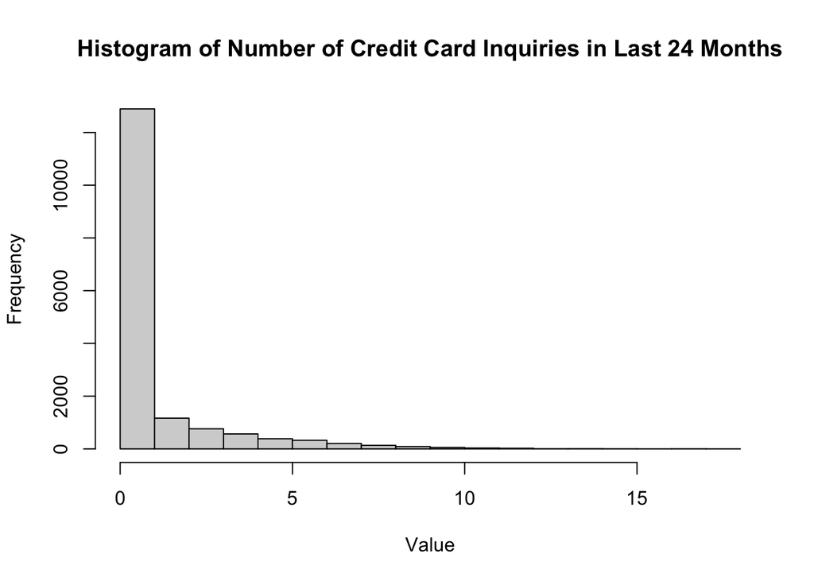

```r
hist(loan$num_card_inq_24_month, main = "Histogram of Number of Credit Card Inquiries in Last 24 Months", xlab = "Value")
```

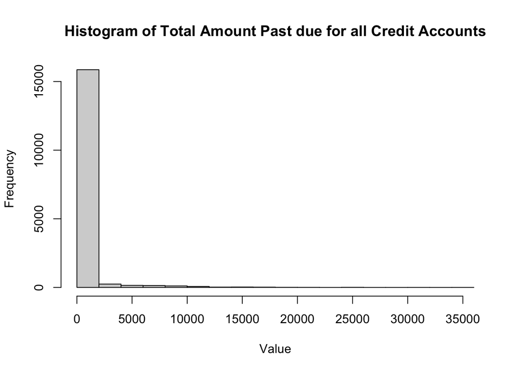

```r
hist(loan$tot_amount_currently_past_due, main = "Histogram of Total Amount Past due for all Credit Accounts", xlab = "Value")
```

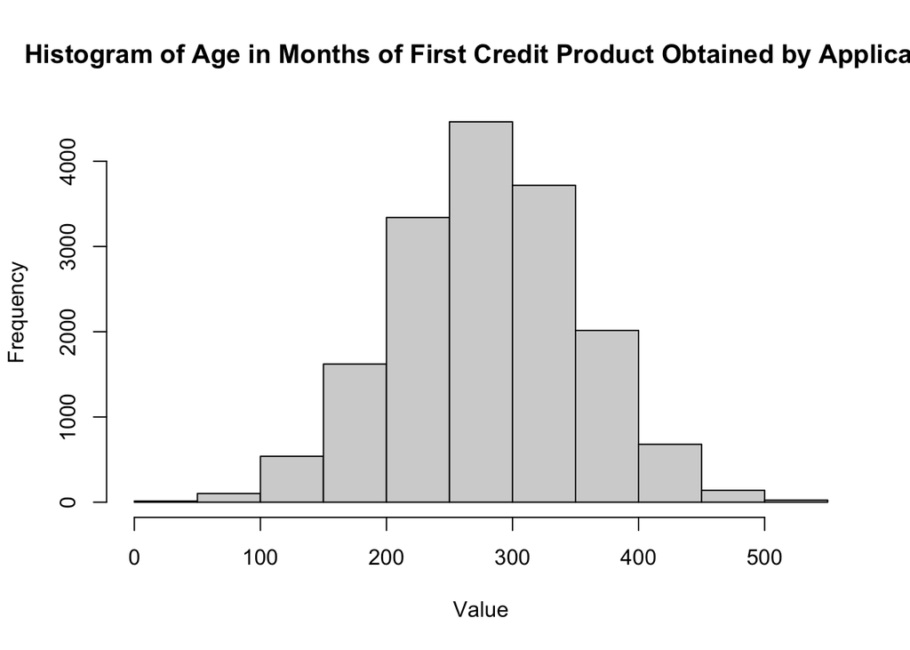

```r
hist(loan$credit_age, main = "Histogram of Age in Months of First Credit Product Obtained by Applicant", xlab = "Value")
```

```r
#The shapes of the histograms do confirm the skewness
```

4. How would your convert the “rep_education” column into numerical data? Name two ways.

```r
# 1: using the table function
# 2: using dplyr
education_counts_table = table(loan$rep_education)
print(education_counts_table)
```

```
##
##     college    graduate high_school       other
##       10104        2026        4403         120
```

## 3: Data Visualization

For every graph in this section, remember to label your axes and to include a title. Feel free to play around with graphics and parameters. Have fun and explore!

1. Plot a bar graph for the “Def_Ind” column and describe it.

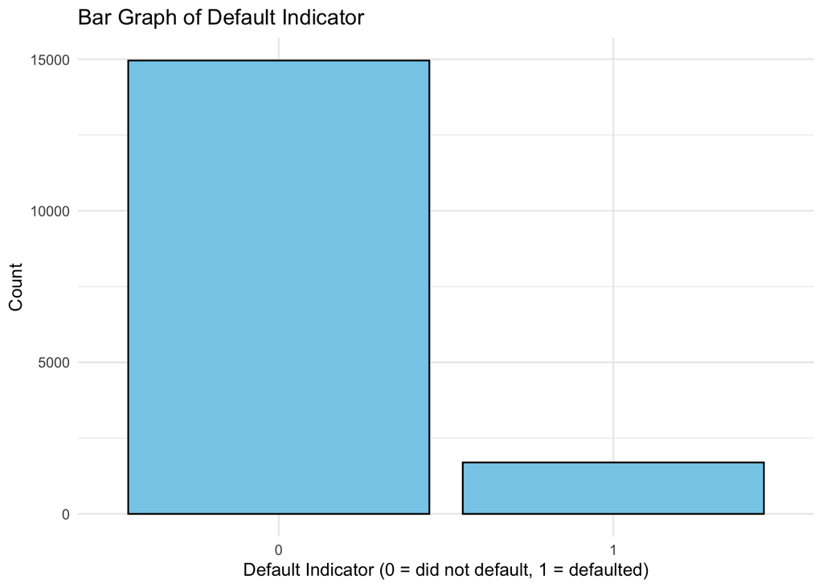

```r
library("ggplot2")
ggplot(loan, aes(x = factor(Def_ind))) +
  geom_bar(fill = "skyblue", color = "black") +
  labs(title = "Bar Graph of Default Indicator",
       x = "Default Indicator (0 = did not default, 1 = defaulted)" ,
       y = "Count") +
  theme_minimal()
```

```r
#Clearly, a significantly larger portion of those applying for credit have not defaulted on any other credit in the past 18 months
```

2. Plot a bar graph for the “rep_education” column and describe it

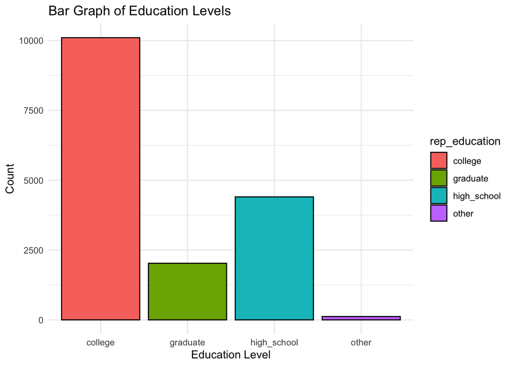

```r
ggplot(loan, aes(x = rep_education, fill = rep_education)) +
  geom_bar(color = "black") +
  labs(title = "Bar Graph of Education Levels",
       x = "Education Level",
       y = "Count") +
  theme_minimal()
```